# FRE 9733 - Homework 1

Deniz Kural

February 10, 2021

##### **Exploring Properties of Dataframe Test or Longley Dataset**

```r
test=data.frame(longley) #Load the Longley Dataset into `Test` Dataframe
str(test) #The Structure and Variable Types
```

```
## 'data.frame':    16 obs. of  7 variables:
##  $ GNP.deflator: num  83 88.5 88.2 89.5 96.2 ...
##  $ GNP         : num  234 259 258 285 329 ...
##  $ Unemployed  : num  236 232 368 335 210 ...
##  $ Armed.Forces: num  159 146 162 165 310 ...
##  $ Population  : num  108 109 110 111 112 ...
##  $ Year        : int  1947 1948 1949 1950 1951 1952 1953 1954 1955 1956 ...
##  $ Employed    : num  60.3 61.1 60.2 61.2 63.2 ...
```

```r
head(test) #Displaying first 5 rows of Test -Longley- Dataframe
```

```
##      GNP.deflator     GNP Unemployed Armed.Forces Population Year Employed
## 1947         83.0 234.289      235.6        159.0    107.608 1947   60.323
## 1948         88.5 259.426      232.5        145.6    108.632 1948   61.122
## 1949         88.2 258.054      368.2        161.6    109.773 1949   60.171
## 1950         89.5 284.599      335.1        165.0    110.929 1950   61.187
## 1951         96.2 328.975      209.9        309.9    112.075 1951   63.221
## 1952         98.1 346.999      193.2        359.4    113.270 1952   63.639
```

```r
summary(test) #Summary of DataFrame Test - Statistical Properties-
```

```
##   GNP.deflator         GNP          Unemployed     Armed.Forces
##  Min.   : 83.00   Min.   :234.3   Min.   :187.0   Min.   :145.6
##  1st Qu.: 94.53   1st Qu.:317.9   1st Qu.:234.8   1st Qu.:229.8
##  Median :100.60   Median :381.4   Median :314.4   Median :271.8
##  Mean   :101.68   Mean   :387.7   Mean   :319.3   Mean   :260.7
##  3rd Qu.:111.25   3rd Qu.:454.1   3rd Qu.:384.2   3rd Qu.:306.1
##  Max.   :116.90   Max.   :554.9   Max.   :480.6   Max.   :359.4
##    Population         Year         Employed
##  Min.   :107.6   Min.   :1947   Min.   :60.17
##  1st Qu.:111.8   1st Qu.:1951   1st Qu.:62.71
##  Median :116.8   Median :1954   Median :65.50
##  Mean   :117.4   Mean   :1954   Mean   :65.32
##  3rd Qu.:122.3   3rd Qu.:1958   3rd Qu.:68.29
##  Max.   :130.1   Max.   :1962   Max.   :70.55
```

```r
dim(test) #Dimensions of Test Dataframe
```

```
## [1] 16  7
```

```r
nrow(test) #Row size of Test Dataset
```

```
## [1] 16
```

```r
ncol(test) #Column size of Test Dataset
```

```
## [1] 7
```

```r
names(test) #Names of Columns of Dataset
```

```
## [1] "GNP.deflator" "GNP"          "Unemployed"   "Armed.Forces"
## [5] "Population"   "Year"         "Employed"
```

##### **Histogram of Armed Forces in Test Dataframe**

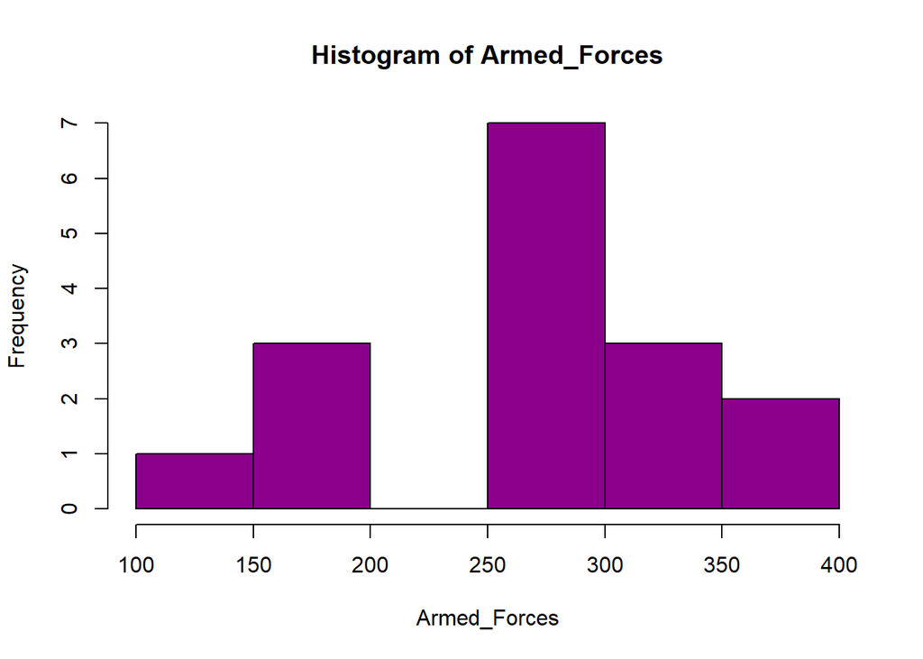

```r
Armed_Forces <- test$Armed.Forces
hist(Armed_Forces,
     col='darkmagenta')
```

###### **Create a Correlation Matrix of all Variables**

```r
cor_matrix <- cor(test)
round(cor_matrix,2)
```

```
##              GNP.deflator  GNP Unemployed Armed.Forces Population Year
## GNP.deflator         1.00 0.99       0.62         0.46       0.98 0.99
## GNP                  0.99 1.00       0.60         0.45       0.99 1.00
## Unemployed           0.62 0.60       1.00        -0.18       0.69 0.67
## Armed.Forces         0.46 0.45      -0.18         1.00       0.36 0.42
## Population           0.98 0.99       0.69         0.36       1.00 0.99
## Year                 0.99 1.00       0.67         0.42       0.99 1.00
## Employed             0.97 0.98       0.50         0.46       0.96 0.97
##              Employed
## GNP.deflator     0.97
## GNP              0.98
## Unemployed       0.50
## Armed.Forces     0.46
## Population       0.96
## Year             0.97
## Employed         1.00
```

##### **Linear Regression on ‘Employed’ Variable of Test Dataframe**

```r
olsFit <- lm(Employed ~., test) #Fit the model by OLS Regression
```

##### **Interpretation of the Results by statistics of Regression**

```r
summary(olsFit) #Summary of OLS Fit
```

```
##
## Call:
## lm(formula = Employed ~ ., data = test)
##
## Residuals:
##      Min       1Q   Median       3Q      Max
## -0.41011 -0.15767 -0.02816  0.10155  0.45539
##
## Coefficients:
##                Estimate Std. Error t value Pr(>|t|)
## (Intercept)  -3.482e+03  8.904e+02  -3.911 0.003560 **
## GNP.deflator  1.506e-02  8.492e-02   0.177 0.863141
## GNP          -3.582e-02  3.349e-02  -1.070 0.312681
## Unemployed   -2.020e-02  4.884e-03  -4.136 0.002535 **
## Armed.Forces -1.033e-02  2.143e-03  -4.822 0.000944 ***
## Population   -5.110e-02  2.261e-01  -0.226 0.826212
## Year          1.829e+00  4.555e-01   4.016 0.003037 **
## ---
## Signif. codes:  0 '***' 0.001 '**' 0.01 '*' 0.05 '.' 0.1 ' ' 1
##
## Residual standard error: 0.3049 on 9 degrees of freedom
## Multiple R-squared:  0.9955, Adjusted R-squared:  0.9925
## F-statistic: 330.3 on 6 and 9 DF,  p-value: 4.984e-10
```

##### **Interpretation of the Results by MSE - Accuracy of the Model**

```r
test_predict <- predict(olsFit,test) #Prediction of Employed from the Built Model
MSE_test <- mean((test$Employed-test_predict)^2) #Find MSE Score of Model
print(MSE_test) #Print-Display the MSE score
```

```
## [1] 0.0522765
```

When we test the built model with Mean Square Error (MSE), we get an error of 0.0522765 which is considerably low and we can say that our predicted responses are “close” enough to true responses.

##### **Visualization of the Result**

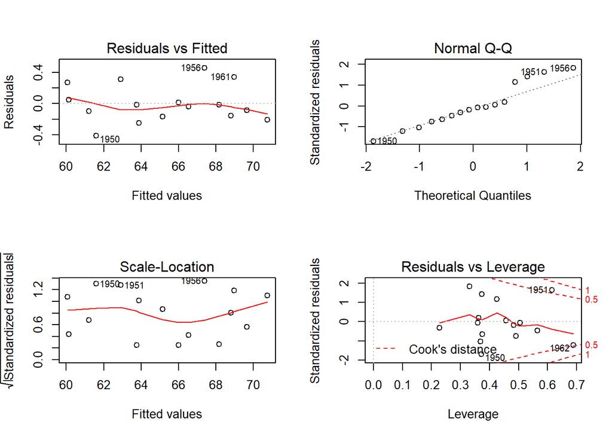

```r
par(mfrow=c(2,2))
plot(olsFit)
```

There are 4 plots that can be observed above. From the figures, we can say that although there is a slight non-linearity in the model, using linear regression is acceptable as regression line is almost smooth (non-linear). There are some outliers that can be observed from the Figure. These outliers specifically belong to 1950,1951 and 1956. However, to be stated as outlier form standardized residuals graph, we need to have larger values (larger than 3 studentized residuals are accepted as an outlier). If we look at the leverage graph, we can not see an higly leveraged point.